# Online shoppers analysis

Stanislaw Czekalski, Szymon Puszcz

In this document we are going to analyze online shoppers data.

It describes 12,330 user sessions browsing online shop. Dataset comes from UCI Machine Learning Repository. Observations are associated with labels indicating whenever current session ended up with consumer buying something or not. Primary task that can be done using this data is to perform classification of sessions, but the aim of our analysys is to explore the data and get knowledge about users’ behaviour.

Raw data looks like this:

```r
df = read.csv("online_shoppers_intention.csv")
head(df, 5)
```

```
##   Administrative Administrative_Duration Informational Informational_Duration
## 1              0                       0             0                      0
## 2              0                       0             0                      0
## 3              0                       0             0                      0
## 4              0                       0             0                      0
## 5              0                       0             0                      0
##   ProductRelated ProductRelated_Duration BounceRates ExitRates PageValues
## 1              1                0.000000        0.20      0.20          0
## 2              2               64.000000        0.00      0.10          0
## 3              1                0.000000        0.20      0.20          0
## 4              2                2.666667        0.05      0.14          0
## 5             10              627.500000        0.02      0.05          0
##   SpecialDay Month OperatingSystems Browser Region TrafficType
## 1          0   Feb                1       1      1           1
## 2          0   Feb                2       2      1           2
## 3          0   Feb                4       1      9           3
## 4          0   Feb                3       2      2           4
## 5          0   Feb                3       3      1           4
##         VisitorType Weekend Revenue
## 1 Returning_Visitor   FALSE   FALSE
## 2 Returning_Visitor   FALSE   FALSE
## 3 Returning_Visitor   FALSE   FALSE
## 4 Returning_Visitor   FALSE   FALSE
## 5 Returning_Visitor    TRUE   FALSE
```

We can see that variables of different types, some of them are categorical. We will set their types to factors.

We should always check for missing values, executing any(is.na(df)) comes in handy.

```
## [1] FALSE
```

There is no missing values in this data.

First thing that must be done is checking class distribution. Most frequently, we do it using bar plot. As one can see, we deal with a problem of imbalanced class distribution.

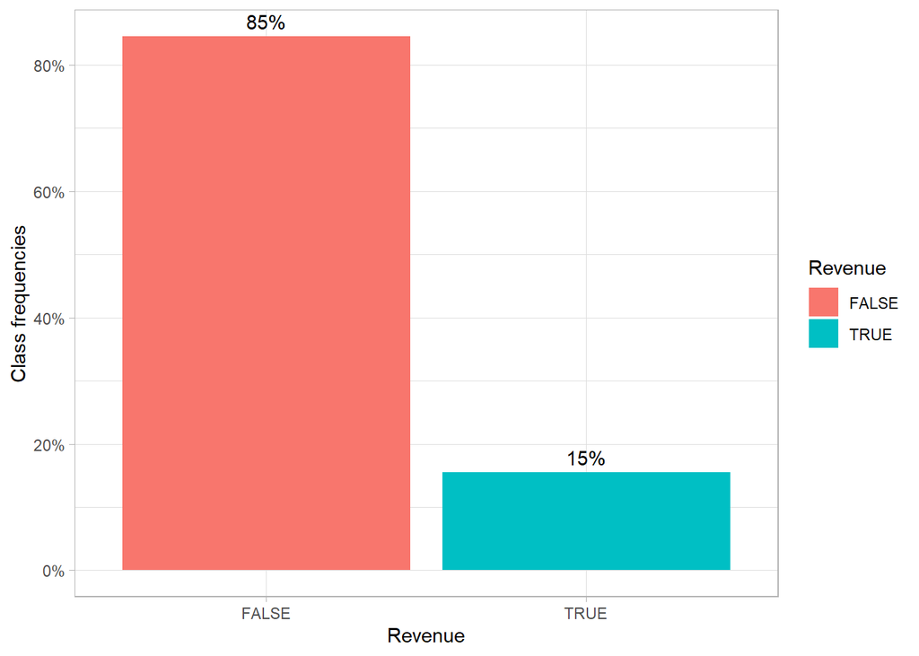

Let’s print summary of variables’ distributions.

```
##  Administrative   Administrative_Duration Informational
##  Min.   : 0.000   Min.   :   0.00         Min.   : 0.0000
##  1st Qu.: 0.000   1st Qu.:   0.00         1st Qu.: 0.0000
##  Median : 1.000   Median :   7.50         Median : 0.0000
##  Mean   : 2.315   Mean   :  80.82         Mean   : 0.5036
##  3rd Qu.: 4.000   3rd Qu.:  93.26         3rd Qu.: 0.0000
##  Max.   :27.000   Max.   :3398.75         Max.   :24.0000
##
##  Informational_Duration ProductRelated   ProductRelated_Duration
##  Min.   :   0.00        Min.   :  0.00   Min.   :    0.0
##  1st Qu.:   0.00        1st Qu.:  7.00   1st Qu.:  184.1
##  Median :   0.00        Median : 18.00   Median :  598.9
##  Mean   :  34.47        Mean   : 31.73   Mean   : 1194.8
##  3rd Qu.:   0.00        3rd Qu.: 38.00   3rd Qu.: 1464.2
##  Max.   :2549.38        Max.   :705.00   Max.   :63973.5
##
##   BounceRates         ExitRates         PageValues        SpecialDay
##  Min.   :0.000000   Min.   :0.00000   Min.   :  0.000   Min.   :0.00000
##  1st Qu.:0.000000   1st Qu.:0.01429   1st Qu.:  0.000   1st Qu.:0.00000
##  Median :0.003112   Median :0.02516   Median :  0.000   Median :0.00000
##  Mean   :0.022191   Mean   :0.04307   Mean   :  5.889   Mean   :0.06143
##  3rd Qu.:0.016813   3rd Qu.:0.05000   3rd Qu.:  0.000   3rd Qu.:0.00000
##  Max.   :0.200000   Max.   :0.20000   Max.   :361.764   Max.   :1.00000
##
##      Month      OperatingSystems    Browser         Region      TrafficType
##  May    :3364   2      :6601     2      :7961   1      :4780   2      :3913
##  Nov    :2998   1      :2585     1      :2462   3      :2403   1      :2451
##  Mar    :1907   3      :2555     4      : 736   4      :1182   3      :2052
##  Dec    :1727   4      : 478     5      : 467   2      :1136   4      :1069
##  Oct    : 549   8      :  79     6      : 174   6      : 805   13     : 738
##  Sep    : 448   6      :  19     10     : 163   7      : 761   10     : 450
##  (Other):1337   (Other):  13     (Other): 367   (Other):1263   (Other):1657
##             VisitorType     Weekend         Revenue
##  New_Visitor      : 1694   Mode :logical   Mode :logical
##  Other            :   85   FALSE:9462      FALSE:10422
##  Returning_Visitor:10551   TRUE :2868      TRUE :1908
##
##
##
##
```

We can see that most user visit parts of the website that are product related. They also spend the most time on them. “**Bounce Rate**”, “**Exit Rate**” and “**Page Value**” are somehow misleading names, after looking up we may discover that they are related to Google Analytics names.

“**Bounce Rate**” describe percentage of visitors that come from Google Analytics, enter the site and then leave (“bounce”) without triggering any other requests to the analytics server during that session.

“**Exit Rate**” feature for a specific web page is calculated as for all pageviews to the page, the percentage that were the last in the session.

The “**Page Value**” feature represents the average value for a web page that a user visited before completing an e-commerce transaction. Values of all “Bounde Rate” and “Exit Rate” are quite low. To furhter investigate this features we can plot their distributions.

Most of values for all three of them are zeros, so we will only plot distribution of non zero values to have a closer look. Additionaly, we decided to split each distribution to two, depending on classes.

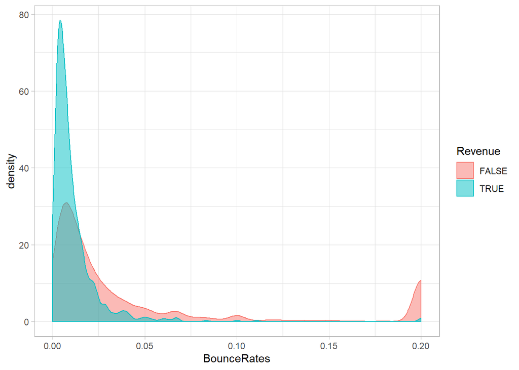

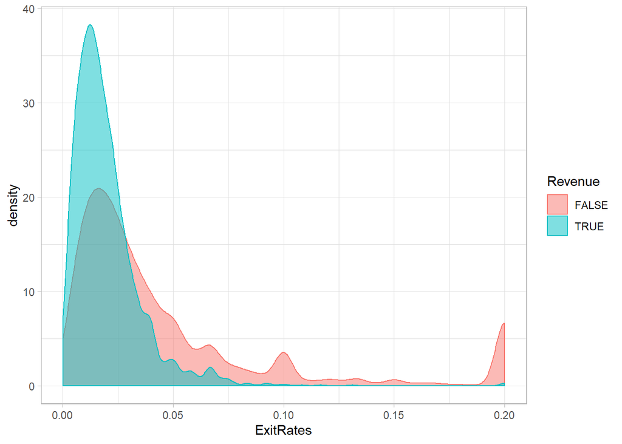

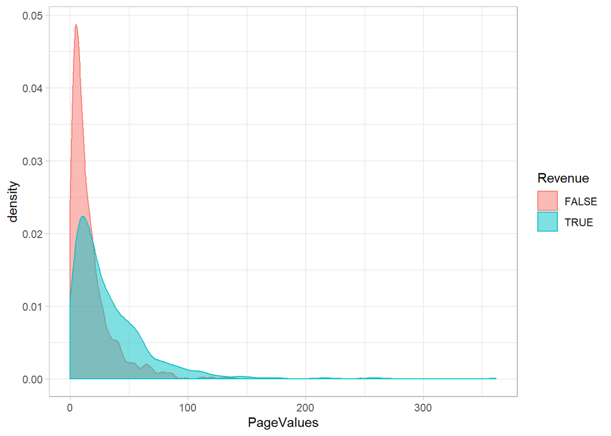

Next, we will take a look at times the user spend on different parts of the website.

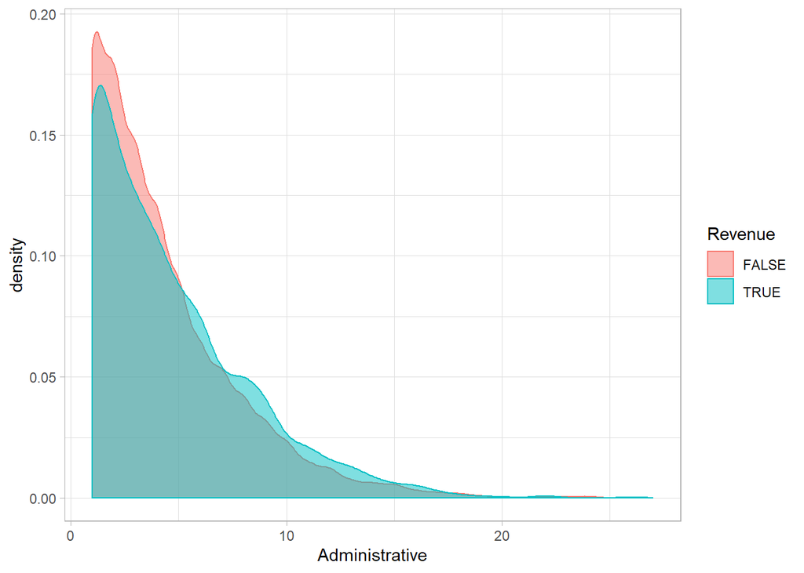

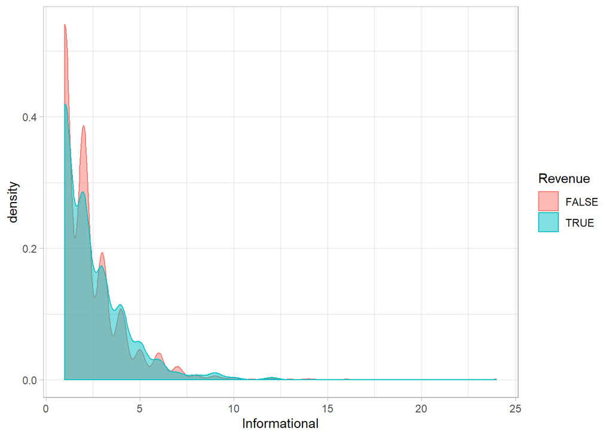

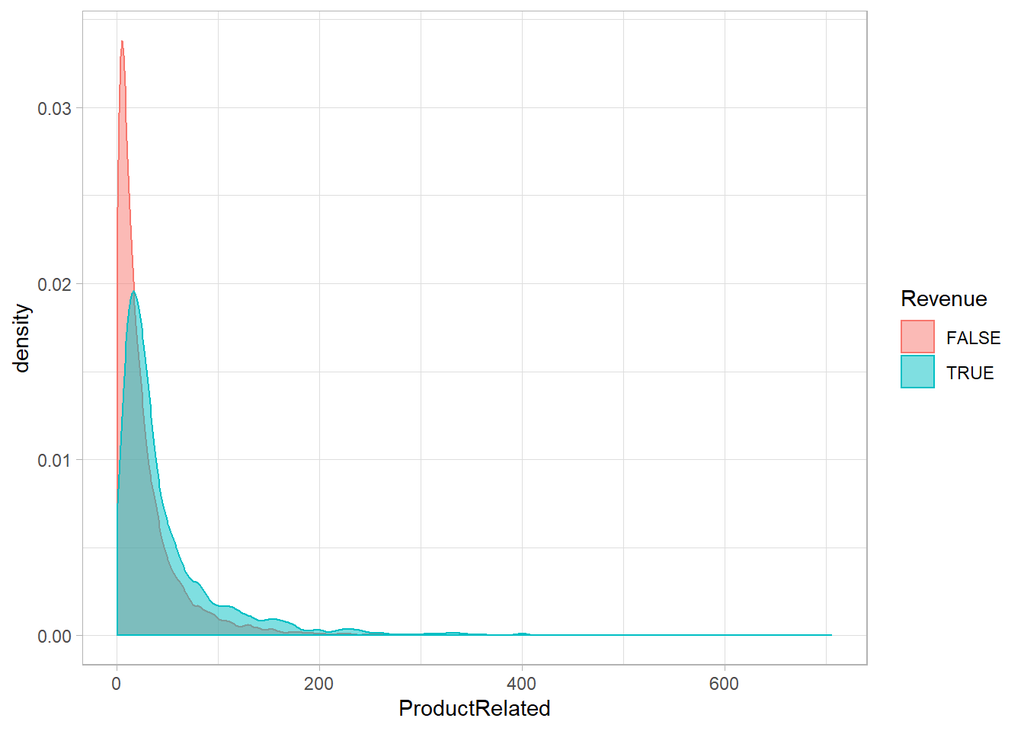

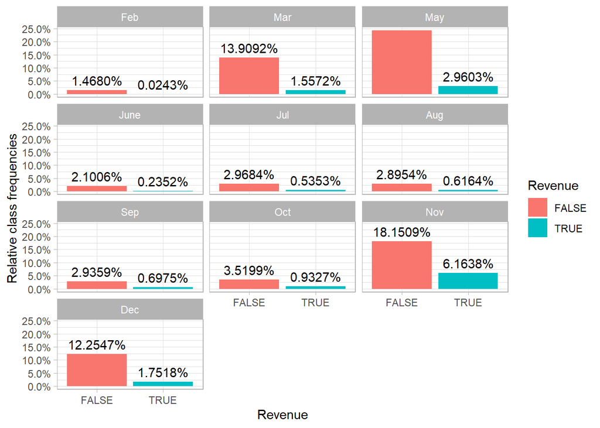

Let’s look at month information. Data is not evenly distributed between months, for some of them we have very little information. For instance, classification model might learn, that there is no point predicting a purchase for session in June, because chances are that no session ending with a purchase from this month will be part of our training set. Using this feature might cause overfitting.

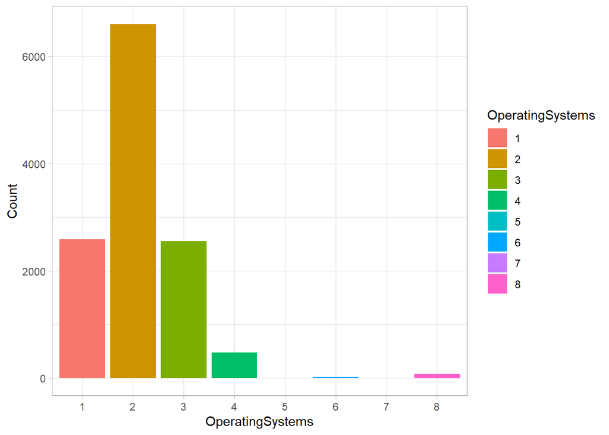

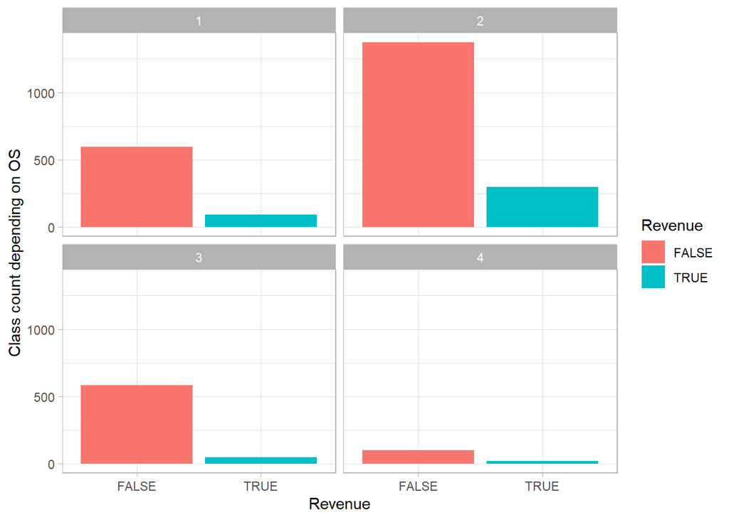

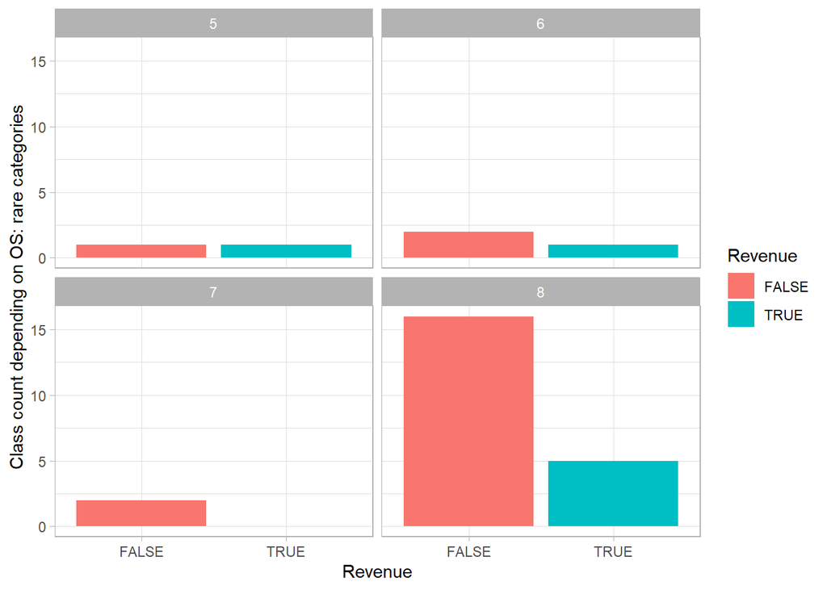

There is 8 kinds of operating systems used by our users. Some of them are much more popular, and some of them are very rare. It may make sense to group all rare categories into one, because alone they are not very informative. We may wrongly conclude that people using OS number 5 buy products more often than other users, but we need to be careful, that little data can be misleading.

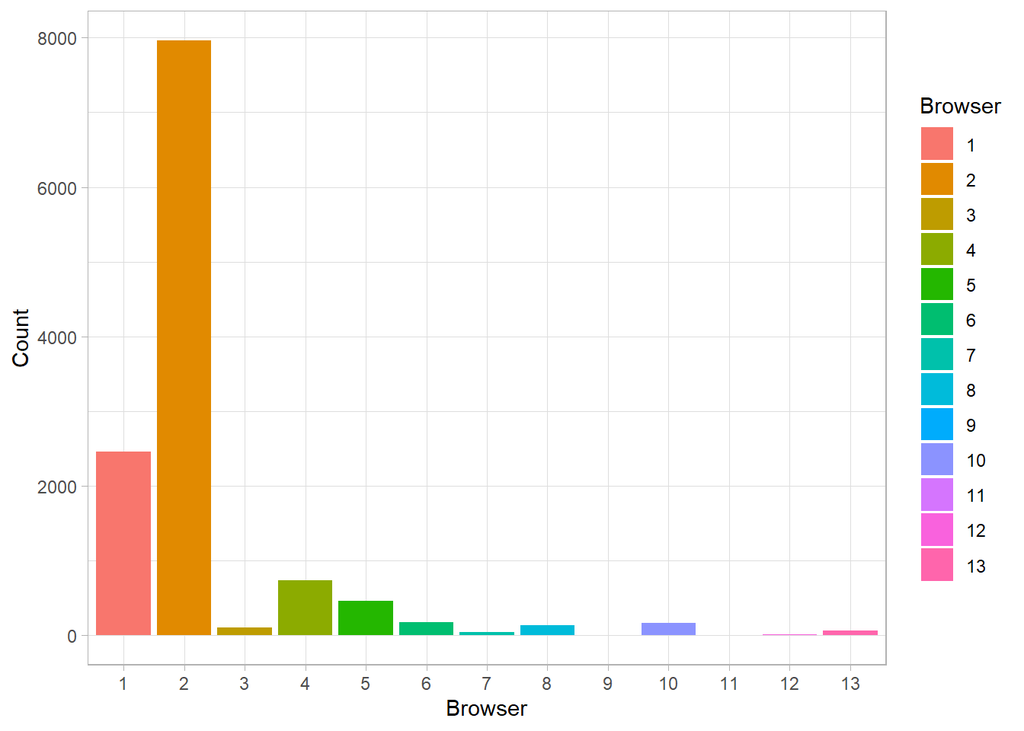

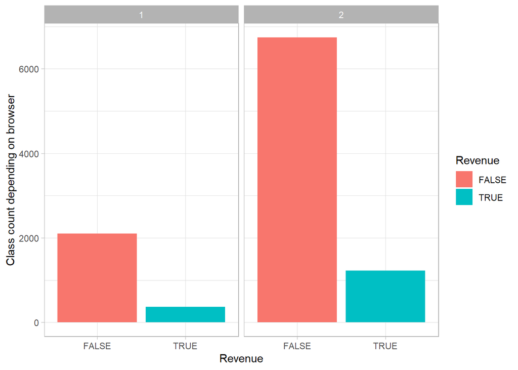

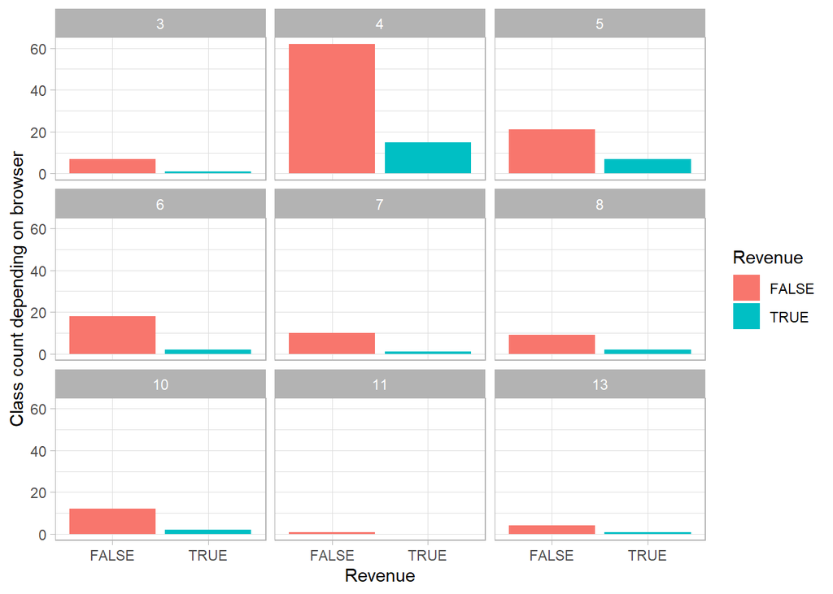

In case of browsers, we have two main categories, and quite a few less popular ones. We draw class distribution in each category to check if we may infer some class information depending on browser type. Once again, grouping rare categories might be desirable

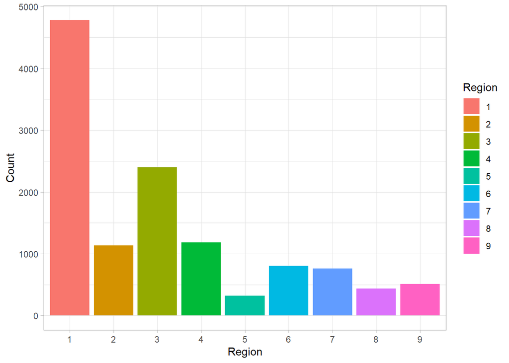

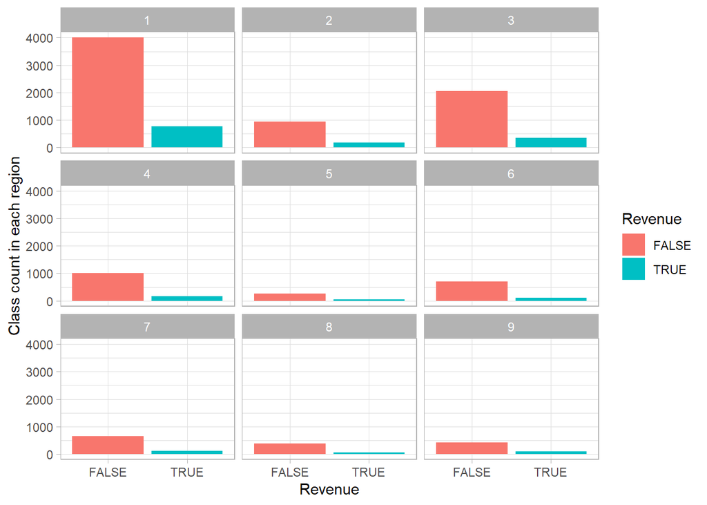

Region distribution is more even compared to OS and browser. Still, class distribution in each region category doesn’t seem to be very helpful in classification.

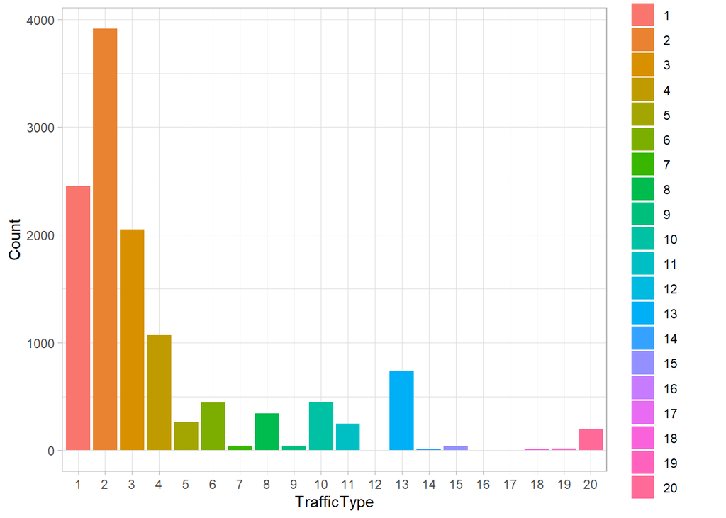

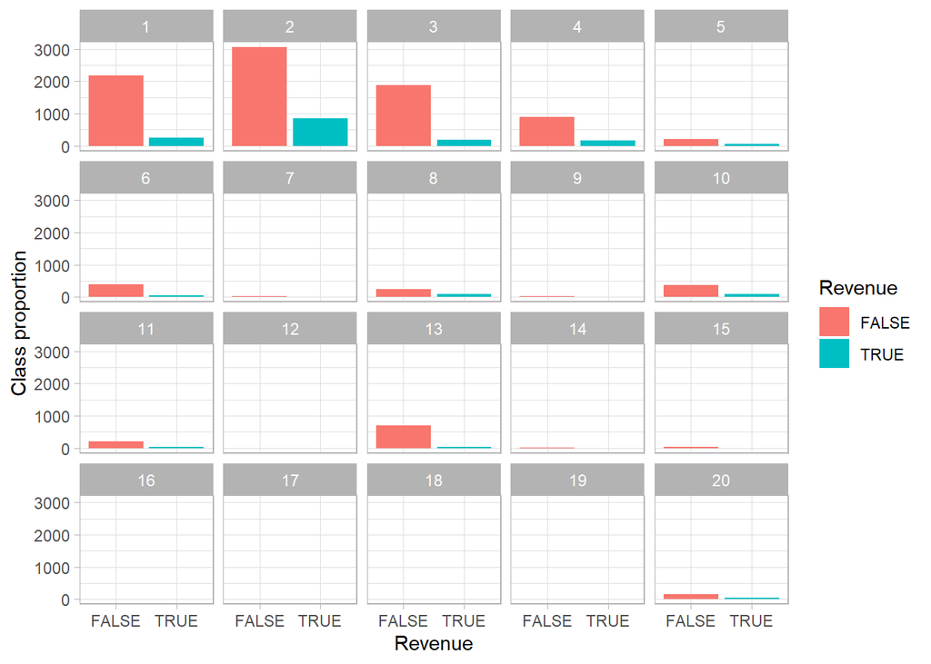

Traffic type distribution is very uneven. This variable might be interesting, especially rare categories might represent untypical user, i.e. administrator or developer. We take a closer look below.

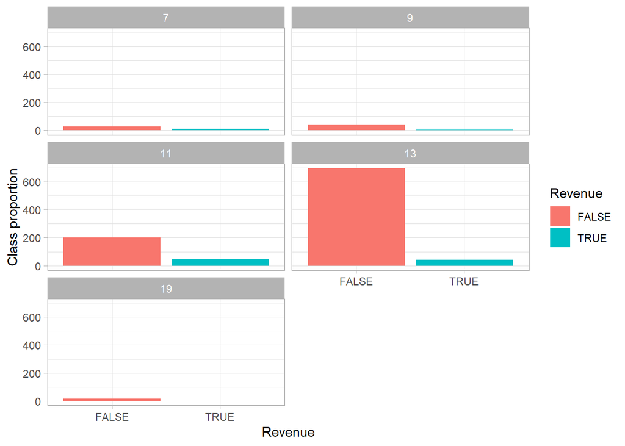

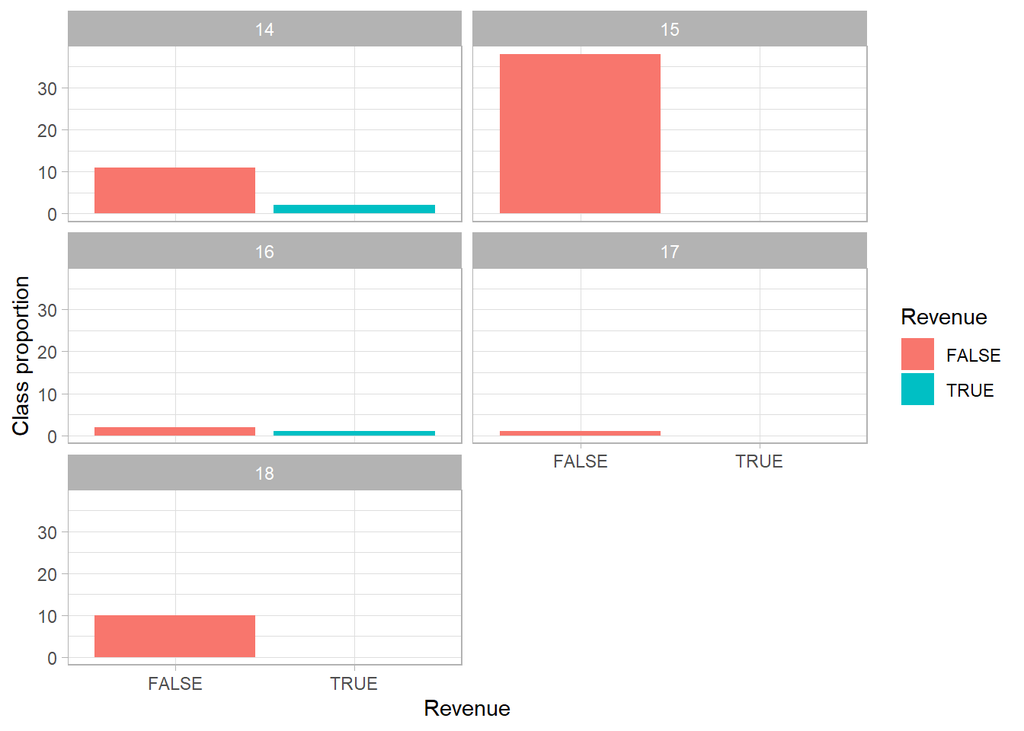

It is hard to reason what some traffic types might represent due to values annonymization. If we had access to description of individual levels of this feature we could discover that some traffic types come from people that are not typical users, and we are not interested in their behaviour. In this case, such observations should be removed from the dataset.

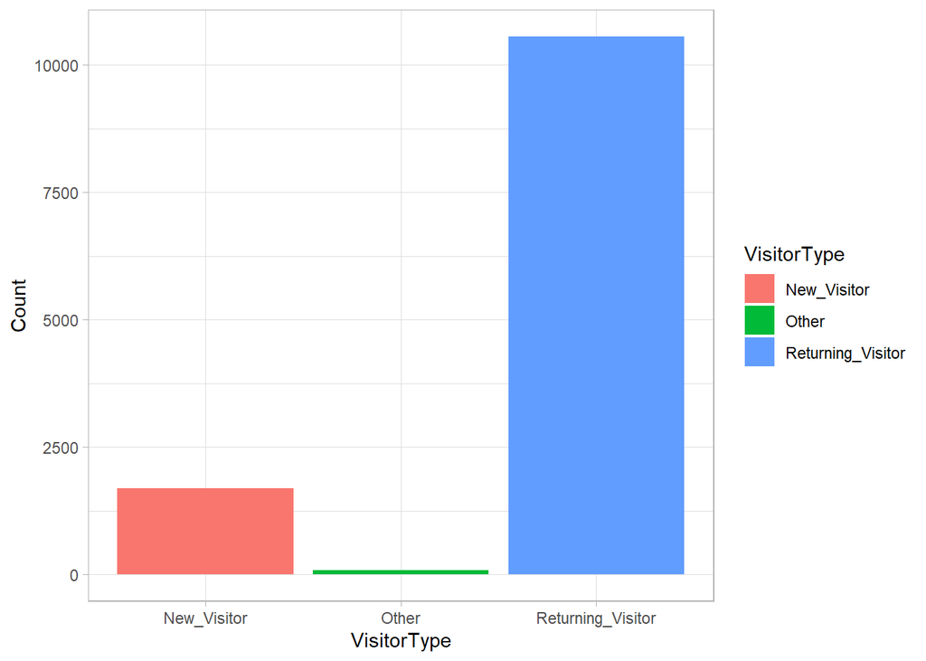

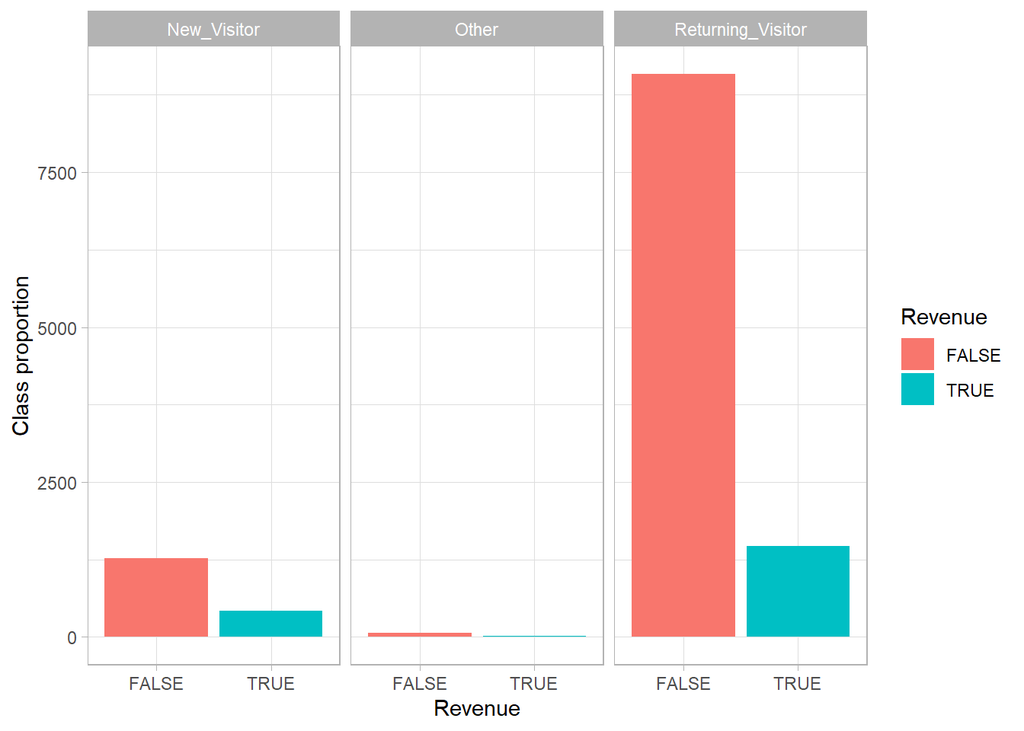

Most of the visitors are returning ones. Category “Other” looks suspicious, in this case we can be pretty sure it represents some abnormal type of users, like administrator or Google crowler, that is not likely to buy something!

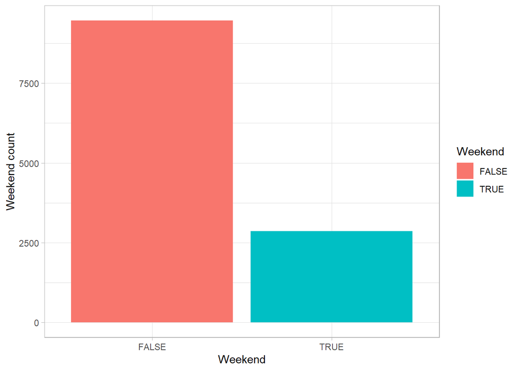

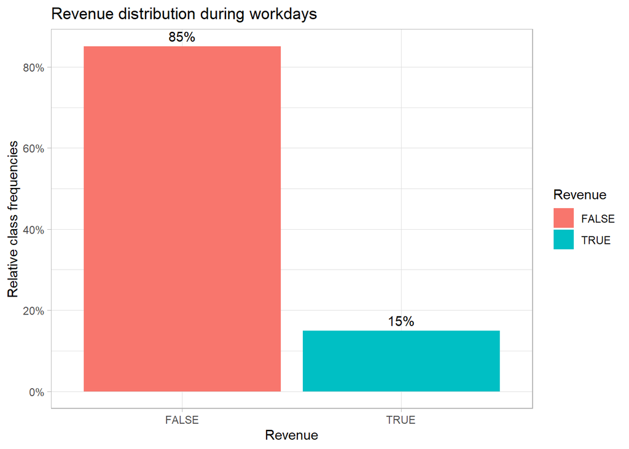

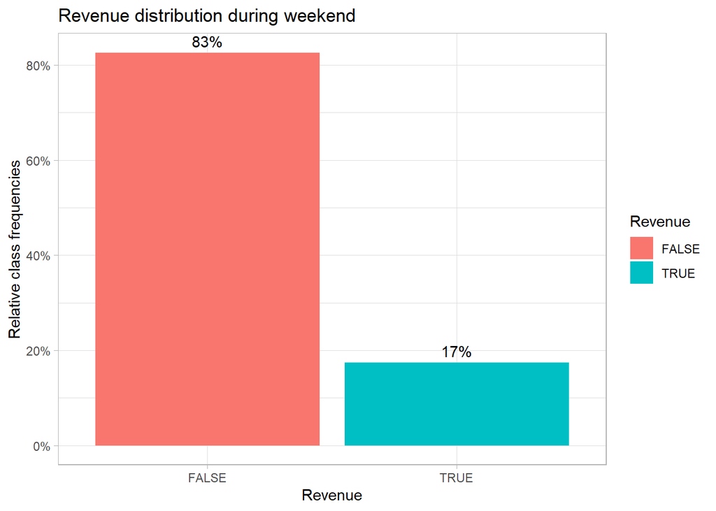

We can see that users that came to the website during the weekend are a little bit more likely to buy something. During the week rate of buyers is about 15%, and for the weekend its 17%. It is not a suprise, during the weekend people usually have more time for shopping.

## Random Forest proximity

In order to get a better understanding of our data, we may try to capture its structure. As we’ve observed our data consists of variables of different types: we have both numeric and categorical features, so it is difficult to come up with a metric suitable for clustering. What we can do instead is to train Random Forest, and get pairwise similarities between objects by counting how many times objects end up in the same leaf node, and use this proximity matrix to perform Multidimensional Scalling, that would create two-dimensional embediing of our data in some abstract space.

```
## ntree      OOB      1      2
##   100:   9.85%  4.37% 39.79%
```

```
##
## Call:
##  randomForest(x = sample_df[, 1:17], y = factor(sample_df$Revenue),      ntree = 100, importance = TRUE, proximity = T, do.trace = 100)
##                Type of random forest: classification
##                      Number of trees: 100
## No. of variables tried at each split: 4
##
##         OOB estimate of  error rate: 9.85%
## Confusion matrix:
##       FALSE TRUE class.error
## FALSE  1993   91  0.04366603
## TRUE    152  230  0.39790576
```

OOB estimate of error suggests that we can trust the model.

## Multidimensional Scalling

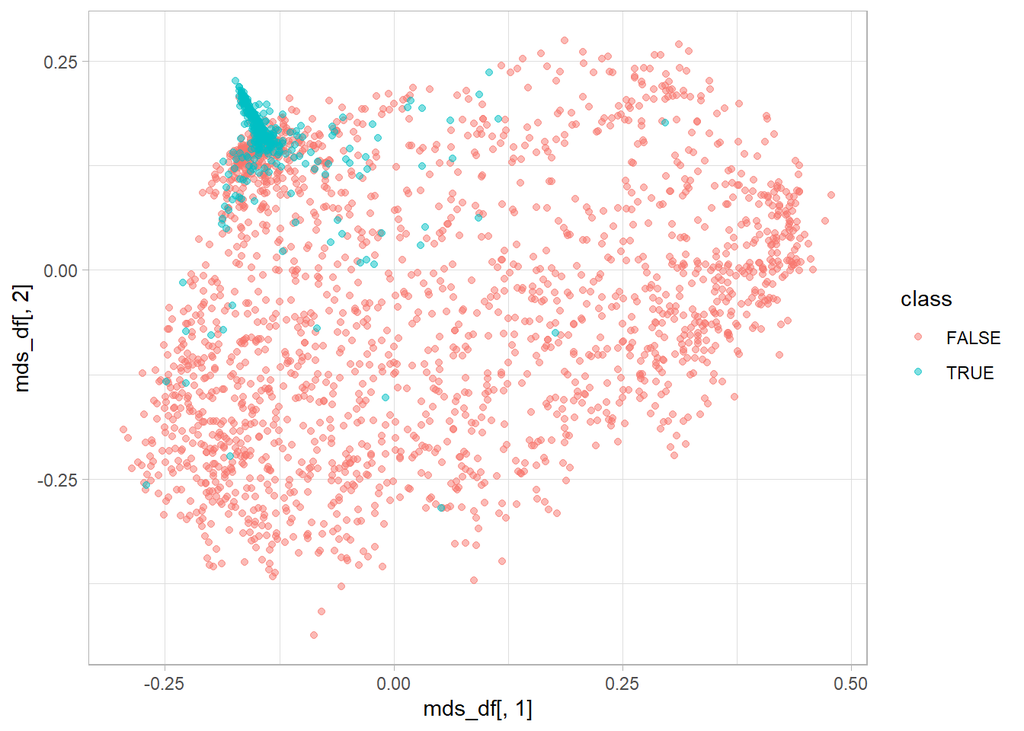

Some structure of our data was obtained. We can see dense cluster of sessions that finished whith purchase, and a whole bunch of other sessions.

Let’s check which features our model considers important.

```r
importance(rf)
```

```
##                               FALSE       TRUE MeanDecreaseAccuracy
## Administrative           7.49600057 -0.9949105           6.76815117
## Administrative_Duration  4.97784413 -0.3478366           4.56904056
## Informational            4.12695761 -1.1488564           3.88965343
## Informational_Duration   4.26666767 -2.1095885           3.47303354
## ProductRelated           7.86912911  0.4364775           7.82151640
## ProductRelated_Duration  7.25810544  3.0572565           8.85351062
## BounceRates              1.61839552  7.2558386           6.31593006
## ExitRates                5.03886809  9.7462937           8.58878827
## PageValues              24.64649258 47.1667242          37.72570664
## SpecialDay              -0.09658892  0.1132535          -0.07849103
## Month                   -0.25098641  7.4007571           4.06514772
## OperatingSystems         3.44238329 -1.1384988           3.12016013
## Browser                  2.78368262 -0.7602219           2.37515952
## Region                   0.97963315 -0.9933461           0.32595627
## TrafficType              1.80029607  4.3274501           4.12779963
## VisitorType              1.25823609 -0.9372661           0.71287263
## Weekend                 -2.20234784 -0.6213121          -2.13813042
##                         MeanDecreaseGini
## Administrative                 26.661101
## Administrative_Duration        27.894736
## Informational                   9.950565
## Informational_Duration         12.508130
## ProductRelated                 39.417138
## ProductRelated_Duration        49.406898
## BounceRates                    32.213203
## ExitRates                      53.432877
## PageValues                    241.945903
## SpecialDay                      1.926054
## Month                          38.294551
## OperatingSystems               12.997915
## Browser                        15.948373
## Region                         33.307178
## TrafficType                    36.238438
## VisitorType                     4.900704
## Weekend                         5.549435
```

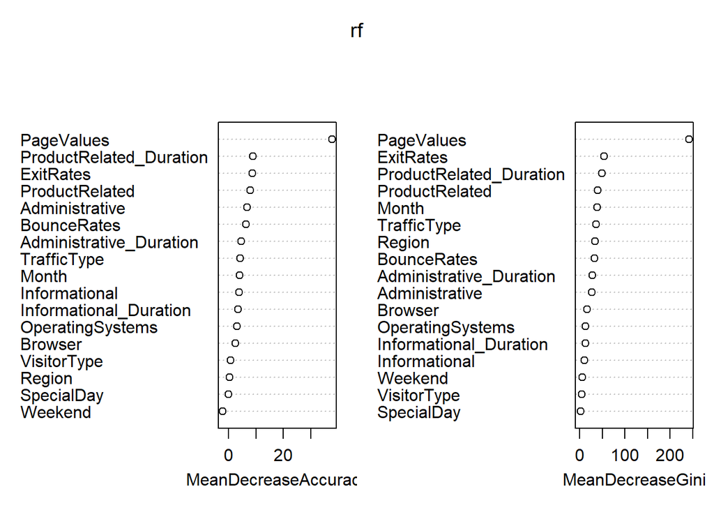

```r
varImpPlot(rf)
```

Page Values seem to be really important, along with time spend on product-related page, laso exit rate and some other features. Month information might be a little bit confusing - our data is not very representative when it comes to this feature.

We will try Multidimensional Scalling on proximity from Random Forest trained only on most important features.

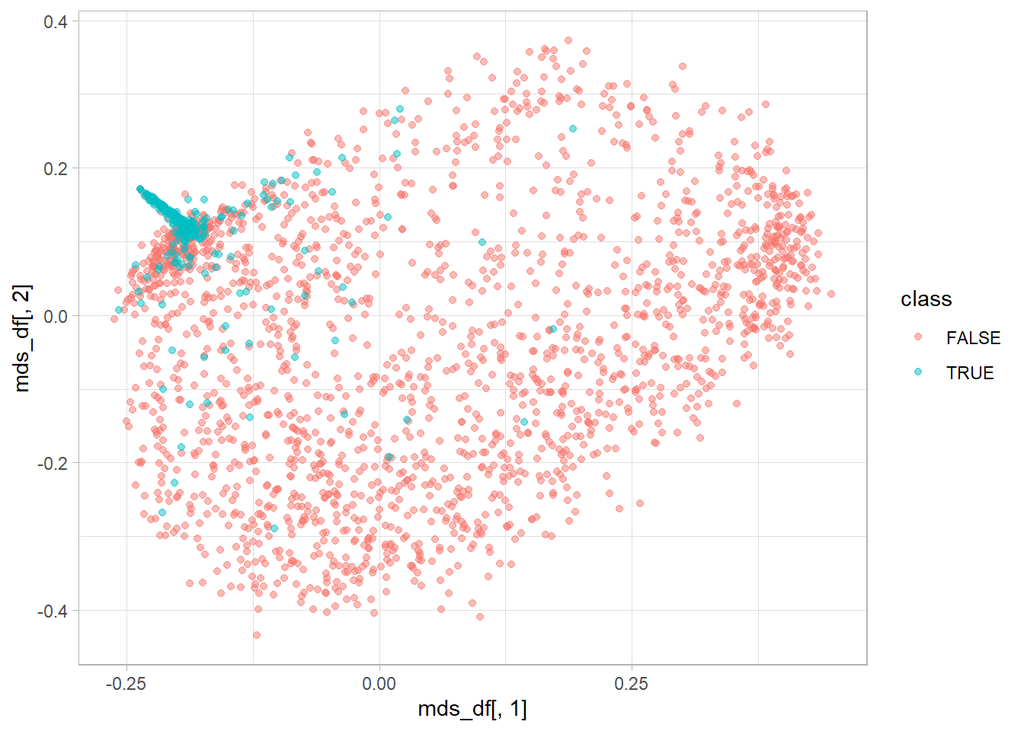

```r
important_cols <- c("PageValues", "ProductRelated_Duration", "ExitRates", "ProductRelated",
                    "Month", "BounceRates", "Administrative_Duration", "TrafficType",
                    "Region", "Administrative")

set.seed(42)
rf_imp <- randomForest(x = sample_df[,important_cols], y = factor(sample_df$Revenue), ntree = 100, proximity = T)
prox_imp <- rf_imp$proximity

set.seed(42)
mds_imp <- cmdscale(1/(prox_imp +1))

mds_df <- data.frame(mds_imp)
mds_df$class <- sample_df$Revenue

mds_df %>%
  ggplot(mapping = aes(x = mds_df[,1], y = mds_df[,2], color = class)) +
  geom_point(alpha=.5) +
  theme_light()
```

## Umap

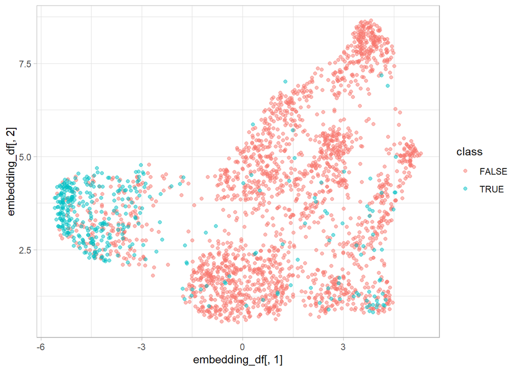

```r
library(umap)
library(reticulate)

dist <- 1/(1+prox)
umap.res <- umap(dist, method = "umap-learn", n_components=2, metric="precomputed", transform_seed=42,
                 n_neighbors=15, min_dist=0.2)
embedding <- umap.res$layout

embedding_df <- data.frame(embedding)
embedding_df$class <- sample_df$Revenue

embedding_df %>%
  ggplot(mapping = aes(x = embedding_df[,1], y = embedding_df[,2], color = class)) +
  geom_point(alpha=.5) +
  theme_light()
```